## The Limits Of Normality Effects On Causal Judgments

Evidence From Continuous Causes

[Kaylee Miceli, Nina Van Rooy, Felipe De Brigard](https://www.imclab.org)

Department of Psychology & Neuroscience, Department of Philosophy  
Duke University

[Kevin O’Neill](https://www.kevingoneill.github.io)

Department of Experimental Psychology, Institute of Cognitive Neuroscience  
University College London

# A familiar example

Icard et al. (2017)

## A formal description

[figure not shown]

$C=1$, $A=1$.

So, $E = 1$.

To what extent did $C=1$ cause $E=1$?

## Two causal structures

**Conjunctive**

$E = \; C \wedge A$

- $C=1$ and $A=1$ are both necessary
- Neither $C=1$ nor $A=1$ is sufficient

**Disjunctive**

$E = \; C \vee A$

- Neither $C=1$ nor $A=1$ are necessary
- Either $C=1$ or $A=1$ is sufficient

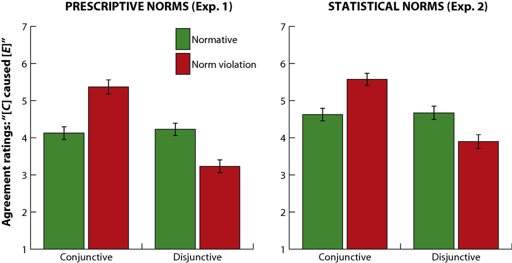

Icard et al. (2017)

# A *slightly* more realistic example

## A formal description

[figure not shown]

$C=c \;=\; A=a$.

$c+a > \theta$, so $E = 1$.

To what extent did $C=c$ cause $E=1$?

## Two special cases

**Conjunctive**

$c+a=\theta+1$

- $C\ge c$ and $A\ge a$ are both necessary
- Neither $C=c$ nor $A=c$ is sufficient

**Disjunctive**

$c=a=\theta+1$

- Neither $C\ge c$ nor $A\ge a$ are necessary
- Either $C=c$ or $A=a$ is sufficient

**Do norms affect causal judgments?**

# Design

[figure not shown]

# Experiment 1

## Manipulations

[figure not shown]

## Participants learned the distribution of events

[figure not shown]

## Participants found abnormal events surprising

[figure not shown]

## No influence of norms on causal judgments

[figure not shown]

# Experiment 2

## Manipulations

[figure not shown]

## Participants learned the distribution of events

[figure not shown]

## Participants found abnormal events surprising

[figure not shown]

## No influence of norms on causal judgments

[figure not shown]

# Conclusions

## Conclusions

- Actual causation is well-studied when events are binary
- But we don’t know much about cases where causes are continuous variables!
- Even when participants learn relevant norms, they don’t affect causal judgments in such contexts

# thanks!

# References

Icard, Thomas F, Jonathan F Kominsky, and Joshua Knobe. 2017. “Normality and Actual Causal Strength.” *Cognition* 161: 80–93.